# 04 - Case Study

## **Introducing the data**

**1. Introducing the data**

In this chapter, you’ll get a chance to put to use what you know about EDA in exploring a new dataset.

**2. Email data set**

The email dataset contains information on all of the emails received by a single email account in a single month. Each email is a case, so we see that this email account received 3,921 emails. Twenty-one different variables were recorded on each email, some of which are numerical, others are categorical. Of primary interest is the first column, a categorical variable indicating whether or not the email is spam. This was created by actually reading through each email individually and deciding if it looked like spam or not. The subsequent columns were easier to create. to multiple is TRUE if the email was addressed to more than one recipient and FALSE otherwise. image is the number of images attached in the email. It’s important that you have a full sense of what each of the variables mean, so you’ll want to start your exercises by reading about them in the help file. One of your guiding questions throughout this chapter is: what characteristics of an email are associated with it being spam? Numerical and graphical summaries are a great way of starting to answer that question. Let’s review the main graphical tools that we have for numerical data.

**3. Histograms**

Histograms take continuous data and aggregate it into bins, then draw a bar to a height that corresponds to the number of cases in that bin. They have a tuning parameter that you should play with, the binwidth, to explore the shape of the distribution at different scales.

If you’re interested in building histograms broken down based on a categorical variable, they’re a good candidate for faceting, which can be done with the facet wrap layer.

**4. Boxplots**

Box plots excel at comparing multiple distributions and this is reflected in the ggplot syntax that requires you to put something on the x axis. If variable has two levels, you’ll get two side-by-side box plots. The box plot uses robust measures, the median and the IQR, to draw the box, and also flags potential outliers for you. A downside, however, is that it can hide more complicated shapes, such as a bimodal distribution.

To get a single box plot, just map x to the number 1.

**5. Density plots**

Density plots summarize the data by drawing a smooth line to represent its shape. Similar to histograms, you can change the smoothness of a density plot by changing the bandwidth parameter, which you can add to the geom density function. These can be faceted just like histograms, or they can be overlaid on one another, by mapping the color of the fill of the distribution to a second variable. If you want the colors to be somewhat transparent, specify an alpha parameter between 0 and 1.

**6. Let’s practice!**

With that brief introduction, let’s dive into this new dataset.

## **Spam and num_char**

Is there an association between spam and the length of an email? You could imagine a story either way:

- *Spam is more likely to be a short message tempting me to click on a link, or*
- *My normal email is likely shorter since I exchange brief emails with my friends all the time.*

Here, you’ll use the `email` dataset to settle that question. Begin by bringing up the help file and learning about all the variables with `?email`.

As you explore the association between spam and the length of an email, use this opportunity to try out linking a `dplyr` chain with the layers in a `ggplot2` object.

**Instructions**

Using the `email` dataset

- Load the packages `ggplot2`, `dplyr`, and `openintro`. Compute appropriate measures of the center and spread of `num_char` for both spam and not-spam using `group_by()` and `summarize()`. No need to name the new columns created by `summarize()`.
- Construct side-by-side box plots to visualize the association between the same two variables. It will be useful to `mutate()` a new column containing a log-transformed version of num_char.

```r
# Load packages
library(ggplot2)
library(dplyr)
library(openintro)

# Compute summary statistics
email %>%
  group_by(spam) %>%
  summarise(median(num_char), IQR(num_char))
```

| spam | median(num_char) | IQR(num_char) |
| --- | --- | --- |
| not-spam | 6.831 | 13.58225 |
| spam | 1.046 | 2.81800 |

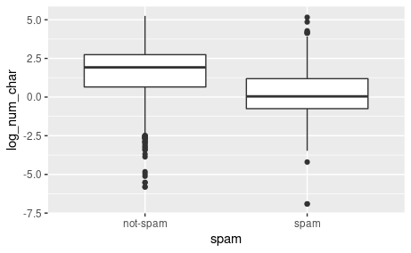

```r
# Create plot
email %>%
  mutate(log_num_char = log(num_char)) %>%
  ggplot(aes(x = spam, y = log_num_char)) +
  geom_boxplot()
```

## **Sapm and !!!**

Let’s look at a more obvious indicator of spam: exclamation marks. `exclaim_mess` contains the number of exclamation marks in each message. Using summary statistics and visualization, see if there is a relationship between this variable and whether or not a message is spam.

Experiment with different types of plots until you find one that is the most informative. Recall that you’ve seen:

- Side-by-side box plots
- Faceted histograms
- Overlaid density plots

**Instructions**

The `email` dataset is still available in your workspace.

- Calculate appropriate measures of the center and spread of `exclaim_mess` for both spam and not-spam using `group_by()` and `summarize()`.
- Construct an appropriate plot to visualize the association between the same two variables, adding in a log-transformation step if necessary.
- If you decide to use a log transformation, remember that `log(0)` is `-Inf` in R, which isn’t a very useful value! You can get around this by adding a small number (like `0.01`) to the quantity inside the `log()` function. This way, your value is never zero. This small shift to the right won’t affect your results.

```r
# Compute center and spread for exclaim_mess by spam
email %>%
  group_by(spam) %>%
  summarise(mean(exclaim_mess), sd(exclaim_mess))
```

| spam | mean(exclaim_mess) | sd(exclaim_mess) |
| --- | --- | --- |
| not-spam | 6.508160 | 47.60968 |
| spam | 7.321526 | 79.87275 |

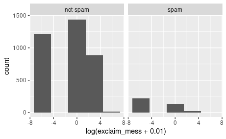

```r
# Create plot for spam and exclaim_mess
email %>%
  ggplot(aes(x = log(exclaim_mess + 0.01))) +
  geom_histogram(bins = 5) +
  facet_wrap(~ spam)
```

## **Check-in 1**

**1. Check-in 1**

Let’s review what you learned in the last several exercises.

**2. Review**

The box plots show the association between whether or not an email is spam and the length of the email, as measured by the log number of characters. In this dataset, the typical spam message is considerably shorter than the non-spam message, but there is still a reasonable amount of overlap in the two distributions of length.

**3. Zero inflation strategies**

One way to view associations between multiple categorical variables is like this, with faceting.

**5. Barchart options**

Another way that we’ve seen is using a stacked bar chart. For that plot, you move the second variable from the facet layer to the fill argument inside the aesthetics function. The other consideration you have to make is if you’re more interested in counts or proportions. If the latter, you’ll want to normalize the plot, which you can do by adding the position equals fill argument to the bar geom. The result is a series of conditional proportions, where you’re conditioning on whichever variable you’re in.

**6 Let’s practice!**

OK, let’s get back to exploring the email dataset.